# Analisis Data Eksploratif Dataset Gapminder

Moh. Rosidi

7/8/2020

# 1 Analisis Data Eksploratif

Analisis data eksploratif (*exploratory data analysis* - EDA) merupakan metode eksplorasi data dengan menggunakan teknik aritmatika sederhana dan teknik grafis dalam meringkas data pengamatan.

EDA bukanlah proses formal dengan seperangkat aturan yang ketat. Lebih dari segalanya, EDA adalah *state of mind*. Selama fase awal EDA Anda harus merasa bebas untuk menyelidiki setiap ide yang ada dalam pikiran kita. Beberapa pertanyaan kita selama proses ini dapat membuahkan hasil (menghasilkan *insight*) dan bahkan ada yang gagal atau tidak terjawab. Saat penjelajahan kita berlanjut, kita akan menemukan beberapa area khusus yang pada akhirnya akan kita laporkan dan komunikasikan dengan orang lain.

EDA adalah bagian penting dari setiap analisis data, bahkan jika pertanyaan diserahkan kepada kita di atas kertas, karena kita selalu perlu menyelidiki kualitas data kita Pembersihan data hanyalah salah satu aplikasi EDA: kita mengajukan pertanyaan tentang apakah data kita memenuhi harapan kita atau tidak.

Selain 2 pertanyaan tersebut, kita dapat pula menambahkan pertanyaan lain ], seperti:

1. Apakah terdapat kolom data yang tidak sesuai?,
2. Apakah terdapat data hilang (*missing value*) pada data kita?,
3. Apakah pada data terdapat observasi yang tidak biasa (*outlier*)?, dll.

Dengan melakukan proses EDA ini diharapkan kita memperoleh gambaran data dan model yang sesuai untuk analisis data tersebut.

# 2 Dataset Gapminder

Pada artikel ini, kita akan melakukan analisis eksploratif pada dataset `Gapminder`. `Gapminder` merupakan kutipan dataset tentang usia harapan hidup, PDB per kapita, dan populasi menurut negara dan benua.

Kolom-kolom pada dataset tersebut, antara lain:

- `country` : nama negara
- `continent` : nama benua
- `year` : tahun dengan rentang 1952 sampai dengan 2007 dengan retang pengukuran tiap 5 tahun
- `lifeExp` : angka harapan hidup dalam satuan `tahun`
- `pop` : populasi
- `gdpPercap` : pendapatan domestik bruto per kapita dalam satuan `US$`

# 3 Persiapan

## 3.1 Library

```r
if(!require(tidyverse)) install.packages("tidyverse")
if(!require(skimr)) install.packages("skimr")
if(!require(DataExplorer)) install.packages("DataExplorer")

library(tidyverse)
library(skimr)
library(DataExplorer)
```

Terdapat tiga buah *library* yang diperlukan dalam tutorial ini, antara lain:

1. `tidyverse` : koleksi paket R yang dirancang untuk ilmu data. Semua paket berbagi filosofi desain, tata bahasa, dan struktur data yang mendasarinya.
2. `skimr` : menyediakan fungsi untuk membuat ringkasan data yang dapat dibaca secara cepat.
3. `DataExplorer` : menyediakan fungsi yang dapat membantu proses otomasi analisis data eksploratif

## 3.2 Import Dataset

Data yang kita miliki memiliki format `.csv`. Untuk megimport data tersebut, kita dapat menggunakan fungsi `read_csv` dari library `readr`.

```r
gapminder <- read_csv("data/gapminder.csv")
```

Untuk mengecek 10 observasi awal dataset tersebut, jalankan sintaks berikut:

```r
gapminder
```

| country | continent | year | lifeExp | pop | gdpPercap |
| --- | --- | --- | --- | --- | --- |
| Afghanistan | Asia | 1952 | 28.80100 | 8425333 | 779.4453 |
| Afghanistan | Asia | 1957 | 30.33200 | 9240934 | 820.8530 |
| Afghanistan | Asia | 1962 | 31.99700 | 10267083 | 853.1007 |
| Afghanistan | Asia | 1967 | 34.02000 | 11537966 | 836.1971 |
| Afghanistan | Asia | 1972 | 36.08800 | 13079460 | 739.9811 |
| Afghanistan | Asia | 1977 | 38.43800 | 14880372 | 786.1134 |
| Afghanistan | Asia | 1982 | 39.85400 | 12881816 | 978.0114 |
| Afghanistan | Asia | 1987 | 40.82200 | 13867957 | 852.3959 |
| Afghanistan | Asia | 1992 | 41.67400 | 16317921 | 649.3414 |
| Afghanistan | Asia | 1997 | 41.76300 | 22227415 | 635.3414 |

[output cut: 1694 more lines]

# 4 Ringkasan Data

Terdapat beberapa fungsi yang dapat digunakan untuk menampilkan ringkasan data pada dataset, antara lain:

- `glimpse` : fungsi dari library `tibble` untuk menampikan struktur data, seperti: jumlah observasi, jumlah kolom, nama kolom dan jenis datanya, dan contoh data pada masing-masing kolom. `glimpse` merupakan versi transpose dari fungsi `print`, kolom ditampilkan per baris dan data pada tiap kolom ditampilkan secara mendatar disamping nama kolomnya.
- `summary` : fungsi dari library `base` untuk menampilkan ringkasan data pada masing-masing kolom , seperti : `mean`, `median`, `min` dan `max`, `1st Qu.` dan `3rd Qu.`, jumlah baris *missing value* pada masing-masing kolom, dan tabel kontingensi.
- `skim` : fungsi dari library `skimr` merupakan alternatif lain dari fungsi `summary`, dengan cepat memberikan gambaran luas dari kerangka data. Fungsi ini menangani berbagai jenis data, mengirimkan satu set fungsi ringkasan yang berbeda berdasarkan pada jenis kolom dalam dataframe.

Berikut adalah penerapan fungsi `glimpse`:

```r
glimpse(gapminder)
```

```
## Rows: 1,704
## Columns: 6
## $ country   <chr> "Afghanistan", "Afghanistan", "Afghanistan", "Afghanistan",…
## $ continent <chr> "Asia", "Asia", "Asia", "Asia", "Asia", "Asia", "Asia", "As…
## $ year      <dbl> 1952, 1957, 1962, 1967, 1972, 1977, 1982, 1987, 1992, 1997,…
## $ lifeExp   <dbl> 28.801, 30.332, 31.997, 34.020, 36.088, 38.438, 39.854, 40.…
## $ pop       <dbl> 8425333, 9240934, 10267083, 11537966, 13079460, 14880372, 1…
## $ gdpPercap <dbl> 779.4453, 820.8530, 853.1007, 836.1971, 739.9811, 786.1134,…
```

Berdasarkan hasil yang diperoleh, dataset `gapminder` memiliki `1704` baris dan `6` kolom. Terdapat dua buah jenis data pada dataset tersebut, yaitu: *character* (`country` dan `continent`) dan `double/numeric`.

Untuk penerapan fungsi `summary`, ditampilkan pada sintaks berikut:

```r
summary(gapminder)
```

```
##    country           continent              year         lifeExp
##  Length:1704        Length:1704        Min.   :1952   Min.   :23.60
##  Class :character   Class :character   1st Qu.:1966   1st Qu.:48.20
##  Mode  :character   Mode  :character   Median :1980   Median :60.71
##                                        Mean   :1980   Mean   :59.47
##                                        3rd Qu.:1993   3rd Qu.:70.85
##                                        Max.   :2007   Max.   :82.60
##       pop              gdpPercap
##  Min.   :6.001e+04   Min.   :   241.2
##  1st Qu.:2.794e+06   1st Qu.:  1202.1
##  Median :7.024e+06   Median :  3531.8
##  Mean   :2.960e+07   Mean   :  7215.3
##  3rd Qu.:1.959e+07   3rd Qu.:  9325.5
##  Max.   :1.319e+09   Max.   :113523.1
```

Fungsi `skim` akan menampilkan ringkasan data yang lebih *tidy* dibandingkan fungsi `summary`. Selain itu, pada jenis data *numeric* dan *integer*, fungsi tersebut akan menampilkan hitogram untuk menggambarkan distribusi dari data *numeric* dan *integer*.

```r
skim(gapminder)
```

Data summary

| Name | gapminder |
| --- | --- |
| Number of rows | 1704 |
| Number of columns | 6 |
| _______________________ |  |
| Column type frequency: |  |
| character | 2 |
| numeric | 4 |
| ________________________ |  |
| Group variables | None |

**Variable type: character**

| skim_variable | n_missing | complete_rate | min | max | empty | n_unique | whitespace |
| --- | --- | --- | --- | --- | --- | --- | --- |
| country | 0 | 1 | 4 | 24 | 0 | 142 | 0 |
| continent | 0 | 1 | 4 | 8 | 0 | 5 | 0 |

**Variable type: numeric**

| skim_variable | n_missing | complete_rate | mean | sd | p0 | p25 | p50 | p75 | p100 | hist |
| --- | --- | --- | --- | --- | --- | --- | --- | --- | --- | --- |
| year | 0 | 1 | 1979.50 | 17.27 | 1952.00 | 1965.75 | 1979.50 | 1993.25 | 2007.0 | ▇▅▅▅▇ |
| lifeExp | 0 | 1 | 59.47 | 12.92 | 23.60 | 48.20 | 60.71 | 70.85 | 82.6 | ▁▆▇▇▇ |
| pop | 0 | 1 | 29601212.32 | 106157896.74 | 60011.00 | 2793664.00 | 7023595.50 | 19585221.75 | 1318683096.0 | ▇▁▁▁▁ |
| gdpPercap | 0 | 1 | 7215.33 | 9857.45 | 241.17 | 1202.06 | 3531.85 | 9325.46 | 113523.1 | ▇▁▁▁▁ |

Berdasarkan output yang dihasilkan, terdapat 4 komponen yang ditampilkan, antara lain:

1. `Data summary`
2. `Column type frequency`
3. `Group variables`
4. Ringkasan data berdasarkan tiap jenis data.

# 5 Variasi

Variasi adalah kecenderungan nilai-nilai variabel berubah dari pengukuran ke pengukuran. Kita dapat melihat variasi dengan mudah dalam kehidupan nyata; jika kita mengukur variabel kontinu dua kali, kita akan mendapatkan dua hasil berbeda. Setiap variabel memiliki pola variasinya sendiri, yang dapat mengungkapkan informasi menarik. Cara terbaik untuk memahami pola itu adalah dengan memvisualisasikan distribusi nilai-nilai variabel.

## 5.1 Data Numerik

Visualisasi yang umum digunakan untuk menggabarkan distribusi data numerik adalah **histogram**. Untuk melakukannya, kita dapat menggunakan fungsi `geom_histogram` dari library `ggplot2`.

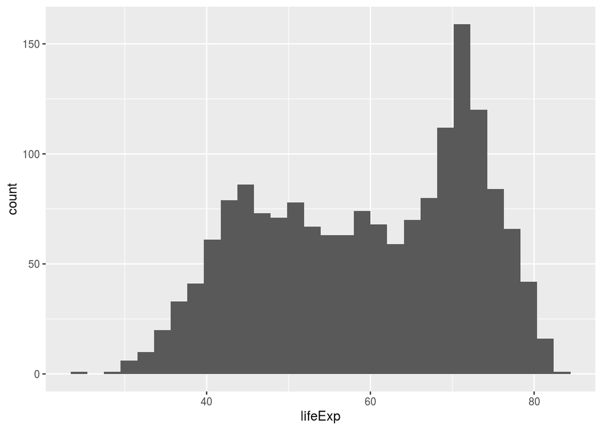

```r
ggplot(gapminder) +
  geom_histogram(aes(x = lifeExp))
```

Secara default, data akan dibagi ke dalam 30 buah rentang nilai (*bins*). Berdasarkan visualisai tersebut, dapat kita lihat bahwa distribusi variabel `lifeExp` memiliki dua buah puncak.

Bagaimana cara memvisualisasikan seluruh variabel numerik ke dalam satu visualisasi? Untuk melakukannya, berikut adalah tahapan yang perlu dilakukan:

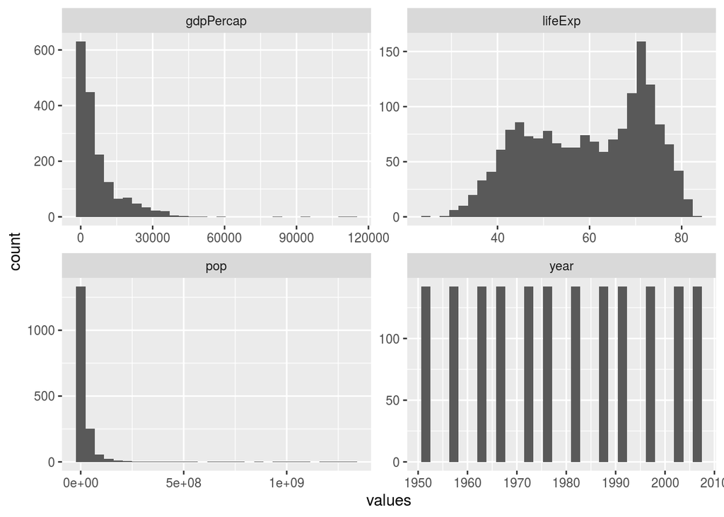

```r
gapminder %>%
  select(!dplyr::starts_with("co")) %>%
  pivot_longer(cols = year:gdpPercap , names_to = "variables", values_to = "values") %>%
  ggplot() +
  geom_histogram(aes(values)) +
  facet_wrap(~variables, scales = "free")
```

## 5.2 Data Kategorikal

Distribusi variabel kategorikan dapat dipelajari dengan cara membuat tabulasi silang (menghitung jumlah observasi pada masing-masing kategori) atau dengan visualisasi menggunakan barplot. Visualisasi digunakan apabila jumlah kategorinya sedikit (tidak lebih dari 5 atau 10).

```r
gapminder %>%
  group_by(country) %>%
  count()
```

| country | n |
| --- | --- |
| Afghanistan | 12 |
| Albania | 12 |
| Algeria | 12 |
| Angola | 12 |
| Argentina | 12 |
| Australia | 12 |
| Austria | 12 |
| Bahrain | 12 |
| Bangladesh | 12 |
| Belgium | 12 |

[output cut: 132 more lines]

Berdasarkan output yang dihasilkan, masing-masing negara dilakukan survey sebanyak 12 kali setiap 5 tahun dan pada data tersebut, distribusi jumlah survey masing-masing negara sama.

Lebih jauh lagi kita juga dapat memeriksa jumlah negara pada masing-masing benua untuk mengetahui distribusi negara yang disurvey pada masing-masing benua. Distribusi jumlah negara pada masing-masing benua dapat dilakukan visualisasi dengan barplot untuk menggambarkan distribusinya sebab jumlah kategorinya yang tidak sebanyak variabel `country`.

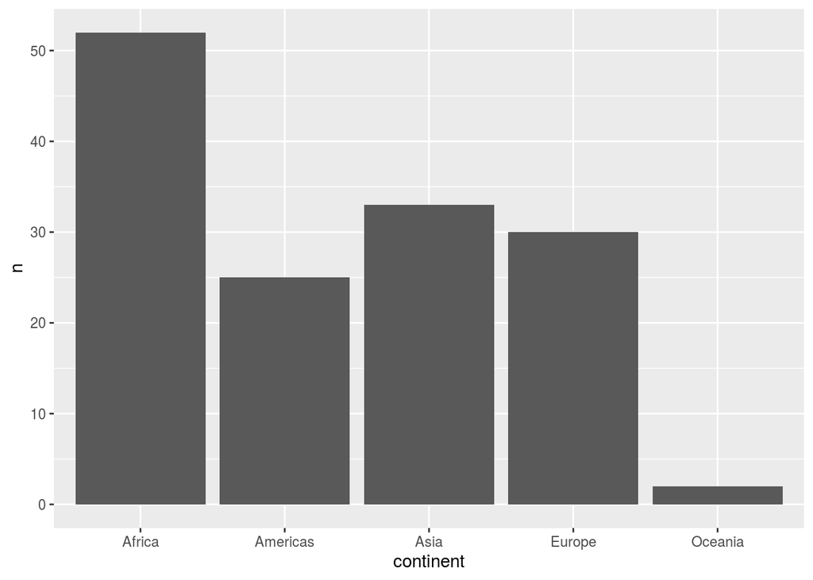

```r
gapminder %>%
  filter(year == 2007) %>%
  select(dplyr::starts_with("co")) %>%
  group_by(continent) %>%
  count() %>%
  ggplot() +
  geom_bar(aes(x = continent, y = n), stat = "identity")
```

Berdasarkan hasil visualisasi dapat diketahui bahwa distribusi jumlah negara yang disurvey atau tercatat tidak seimbang pada masing-masing benua, dimana benua afrika memiliki jumlah negara yang tercatat lebih dari 50 sedangkan oceania hanya 2 negara saja. Kondisi tersebut akan berpengaruh pada performa model yang akan dibentuk dimana benua afrika akan memberikan efek dominan pada model, sedangkan benua oceania memberikan efek paling kecil atau bisa jadi efek yang dihasilkan tidak tertangkap oleh model. Jika model yang dibuat ingin menangkap seluruh efek benua secara merata, proses `over` atau `under sampling` perlu dilakukan berdasarkan variabel `continent`.

# 6 Kovarian

Jika variasi menggambarkan perilaku di dalam suatu variabel, kovariasi menggambarkan perilaku di antara variabel. Kovarian adalah kecenderungan untuk nilai-nilai dari dua atau lebih variabel bervariasi bersama dalam cara yang terkait. Cara terbaik untuk menemukan kovarisasi adalah memvisualisasikan hubungan antara dua variabel atau lebih. Bagaimana kita melakukannya harus kembali tergantung pada jenis variabel yang terlibat.

## 6.1 Kategorikal dan Kontinu

Cara paling mudah untuk memvisualisasikan hubungan antara sebuah variabel kategorikal dengan variabel kontinu adalah dengan menggunakan boxplot. Boxplot merupakan sejenis ringkasan visual untuk distribusi nilai-nilai yang populer di kalangan ahli statistik. Setiap boxplot terdiri dari:

- Sebuah kotak yang membentang dari persentil ke-25 dari distribusi ke persentil ke-75, jarak yang dikenal sebagai rentang interkuartil (IQR). Di tengah kotak adalah garis yang menampilkan median, yaitu persentil ke-50, dari distribusi. Ketiga baris ini memberi kita gambaran tentang distribusi dan apakah distribusinya simetris tentang median atau condong ke satu sisi.
- Poin visual yang menampilkan pengamatan yang jatuh lebih dari 1,5 kali IQR dari kedua sisi kotak. Titik-titik *outlier* ini merupakan titik yang tidak biasa sehingga diplot secara individual.
- Baris (atau kumis) yang memanjang dari setiap ujung kotak dan menuju ke titik non-outlier terjauh dalam distribusi.

sumber: Hadley, 2017

Mari kita coba visualisasikan hubungan antara variabel kategorikal (`continent`) dengan variabel kontinu (`lifeExp`).

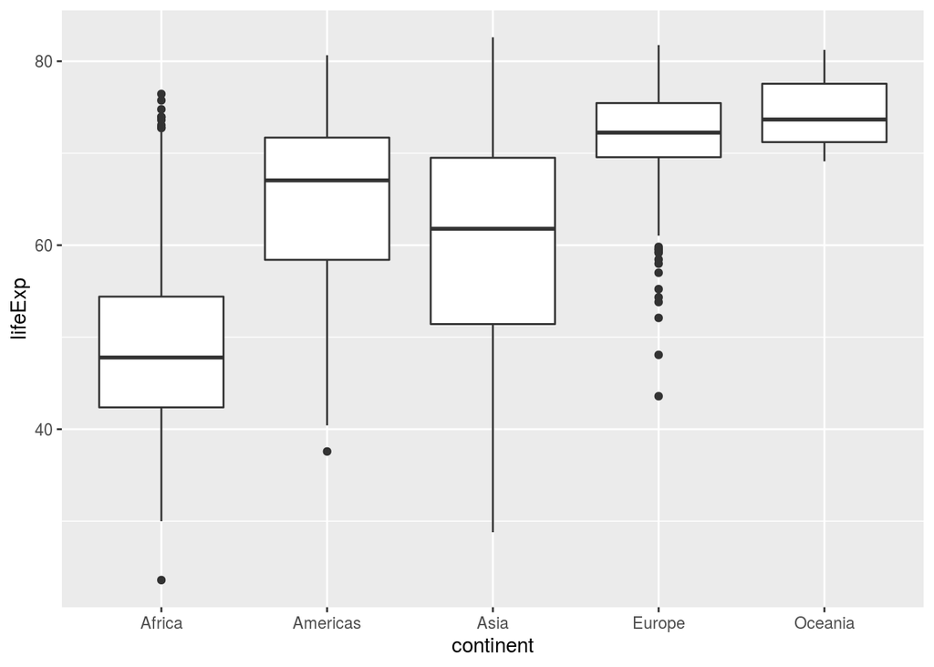

```r
ggplot(gapminder) +
  geom_boxplot(aes(x = continent, y = lifeExp))
```

Berdasarkan visualisasi yang ditampilkan dapat dilihat bahwa benua afrika memiliki median `lifeExp` yang paling rendah dibandingkan benua lainnya. Sedangkan median `lifeExp` pada benua eropa dan oceania relatif sama. Untuk mengetahui apakah nilai media antara satu benua dengan benua lainnya berbeda secara signifikan, kita dapat menambahkan *notch* pada boxplot yang menunjukkan nilai retang keyakinan dari median.

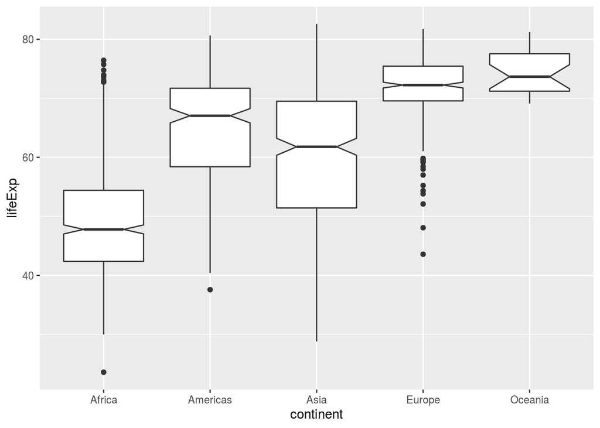

```r
ggplot(gapminder) +
  geom_boxplot(aes(x = continent, y = lifeExp), notch = TRUE)
```

Dapat kita lihat, median `lifeExp` benua eropa dan oceania tidak berbeda secara signifikan yang ditunjukkan dengan rentang median yang saling overlap.

Untuk memvisualisasikan beberapa variabel kontinu dengan sebuah variabel kategorikal dapat dilakukan dengan menggunakan metode yang telah dijelaskan pada subbab visualisasi distribusi data numerik.

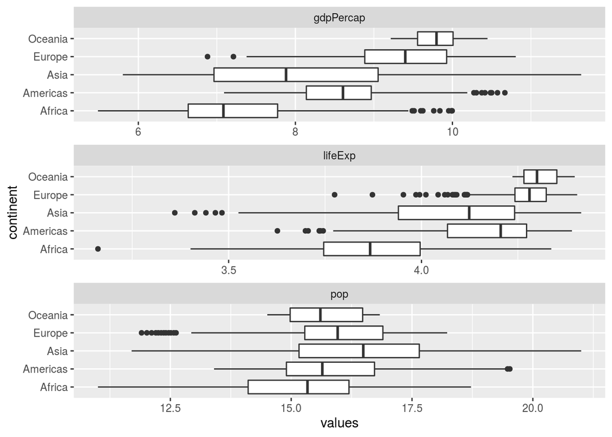

```r
gapminder %>%
  select(continent, lifeExp:gdpPercap) %>%
  # lakukan transformasi logaritmik pada seluruh variabel numerik
  mutate_if(is.numeric, log) %>%
  pivot_longer(cols = lifeExp:gdpPercap, names_to = "variables", values_to = "values") %>%
  ggplot() +
  geom_boxplot(aes(x = continent, y = values)) +
  coord_flip() +
  facet_wrap(~variables, scales = "free", nrow = 3)
```

## 6.2 Kategorikal dan Kategorikal

Untuk melihat kovarian antara dua variabel kategorikal, kita dapat membuat tabulasi silang.

```r
gapminder %>%
  group_by(country, continent) %>%
  count()
```

| country | continent | n |
| --- | --- | --- |
| Afghanistan | Asia | 12 |
| Albania | Europe | 12 |
| Algeria | Africa | 12 |
| Angola | Africa | 12 |
| Argentina | Americas | 12 |
| Australia | Oceania | 12 |
| Austria | Europe | 12 |
| Bahrain | Asia | 12 |
| Bangladesh | Asia | 12 |
| Belgium | Europe | 12 |

[output cut: 132 more lines]

Pada umumnya visualisasi hubungan antara 2 variabel kategroikal dapat dilakukan dengan menggunakan fungsi `geom_count` pada `ggplot`> Perlu dicatat bahwa variabel kategorikal yang divisualisasikan sebaikanya tidak lebih dari 5 atau 10.

[figure not shown]

```r
ggplot(gapminder) +
  geom_count(aes(x = continent, y = country))
```

## 6.3 Kontinu dan Kontinu

Kovarian antara dua variabel kontinu dapat divisualisasikan dengan menggunakan scatterplot. Berikut adalah contoh visualisasi antara variabel `lifeExp` dan log `gdpPercap`.

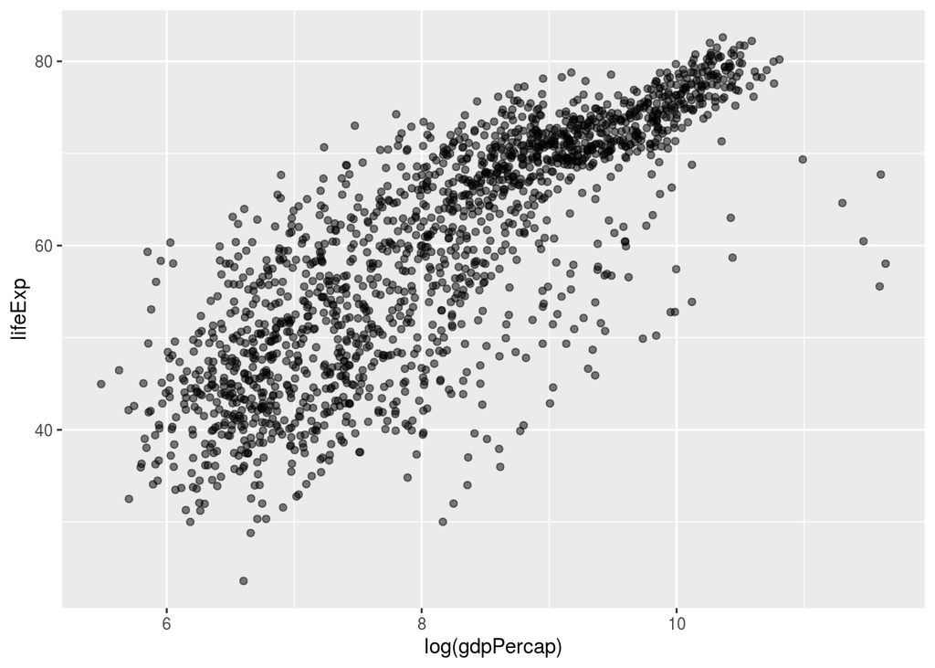

```r
ggplot(gapminder) +
  geom_point(aes(x = log(gdpPercap), y = lifeExp), alpha = 0.5)
```

Berdasarkan visualisasi tersebut dapat kita cermati bahwa negara dengan `gdpPercap` tinggi cenderung memiliki `lifeExp` yang tinggi pula.

Alternatif lainnya yang dapat digunakan untuk mevisualisasikan kovarian antara dua variabel numerik adalah dengan menggunakan heatmap. Berbeda dengan scatterplot, hetamap mevisualisasikan nilai koefisien korelasi anatar dua variabel.

# 7 Analisis Data Exploratif Menggunakan `DataExplorer`

`DataExplorer` merupakan library alternatif yang dapat kita gunakan untuk melakukan otomasi pada proses EDA. Pada `DataExplorer` terdapat sejumlah fungsi yang dapat mereduksi waktu dan jumlah sintaks yang ditulis untuk melihat pola pada data. Berikut adalah contoh sintaks yang dapat kita gunakan:

## 7.1 Laporan

Untuk memperoleh laporan terkait dataset `gapminder`, kita dapat menjalanakan funsgi `create_report`.

```r
create_report(gapminder)
```

Fungsi tersebut akan memberikan kita laporan dalam bentuk format `html` terkait ringkasan data dan visualisasi dari dataset `gapminder`.

## 7.2 Visualisasi

Dibanding menjalankan fungsi `create_report`, kita dapat menggunakan fungsi lainnya secara satu-persatu untuk menghasilkan output yang kita inginkan. Ini berguna ketika kita ingin meletakkan deskripsi pada temuan yang akan kita buat.

```r
# melihat deskripsi dasar dari dataset gapminder
introduce(gapminder)
```

| rows | columns | discrete_columns | continuous_columns | all_missing_columns | total_missing_values | complete_rows | total_observations | memory_usage |
| --- | --- | --- | --- | --- | --- | --- | --- | --- |
| 1704 | 6 | 2 | 4 | 0 | 0 | 1704 | 10224 | 92800 |

Fungsi berikut akan memberikan ringkasan terkait penggunaaan memori pada dataset `gapminder`.

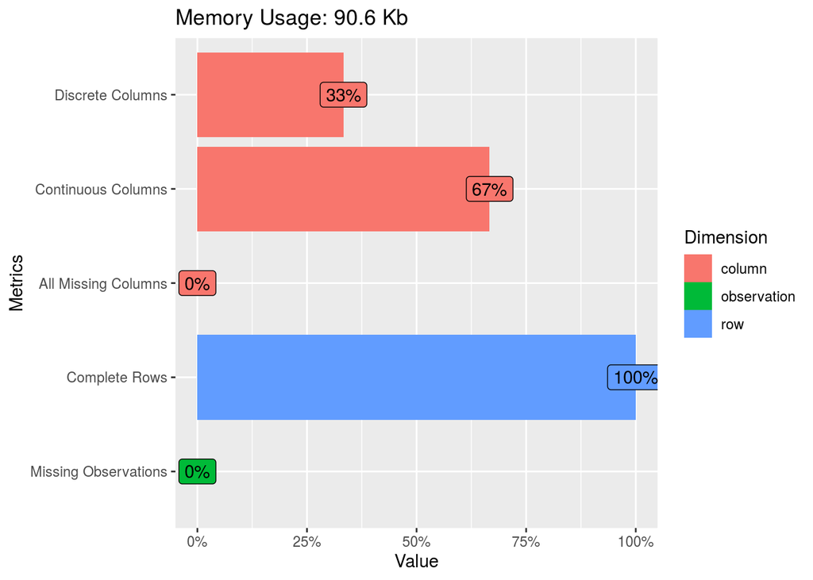

```r
# visualisasi deskripsi dasar dataset `gapminder`
plot_intro(gapminder)
```

Untuk melihat jumlah *missing value* pada data, jalankan fungsi `plot_missing`.

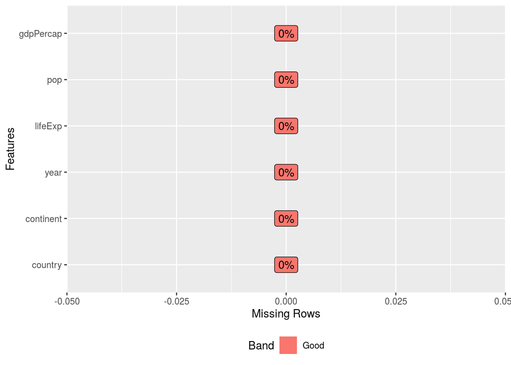

```r
plot_missing(gapminder)
```

Berdasarkan output yang dihasilkan, pada dataset `gapminder` tidak terdapat *missing value*.

Untuk memvisualisasikan variasi pada dataset, kita dapat menggunakan fungsi `plot_bar` dan `plot_histogram`.

```
## 1 columns ignored with more than 50 categories.
## country: 142 categories
```

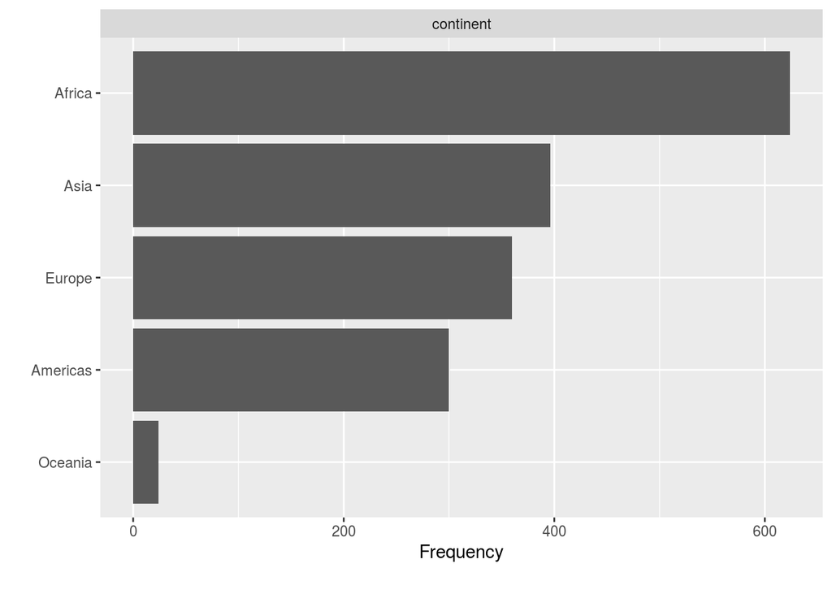

```r
plot_bar(gapminder)
```

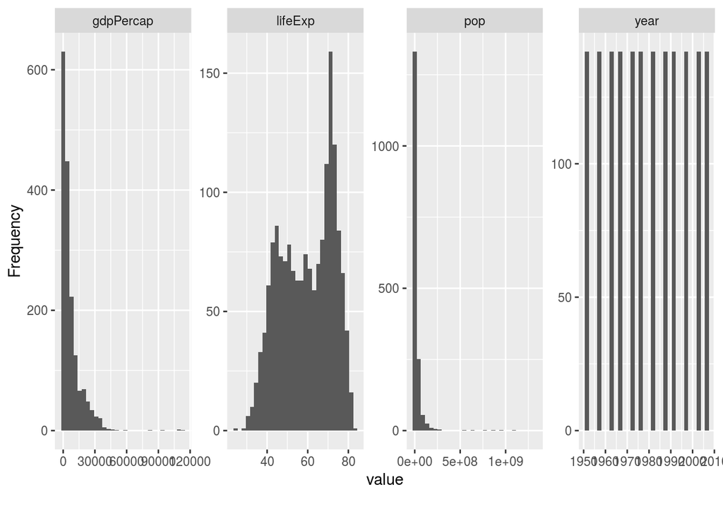

```r
plot_histogram(gapminder)
```

Berdasrakan output yang dihasilkan, variabel `country` tidak divisualisasikan karena memiliki jumlah kategori lebih besar dari 50.

Untuk mwmvisualisikan kovarian antara dua variabel, kita dapat menggunakan fungsi `plot_correlation`, `plot_boxplot`, dan `plot_scatterplot`.

```
## 1 features with more than 20 categories ignored!
## country: 142 categories
```

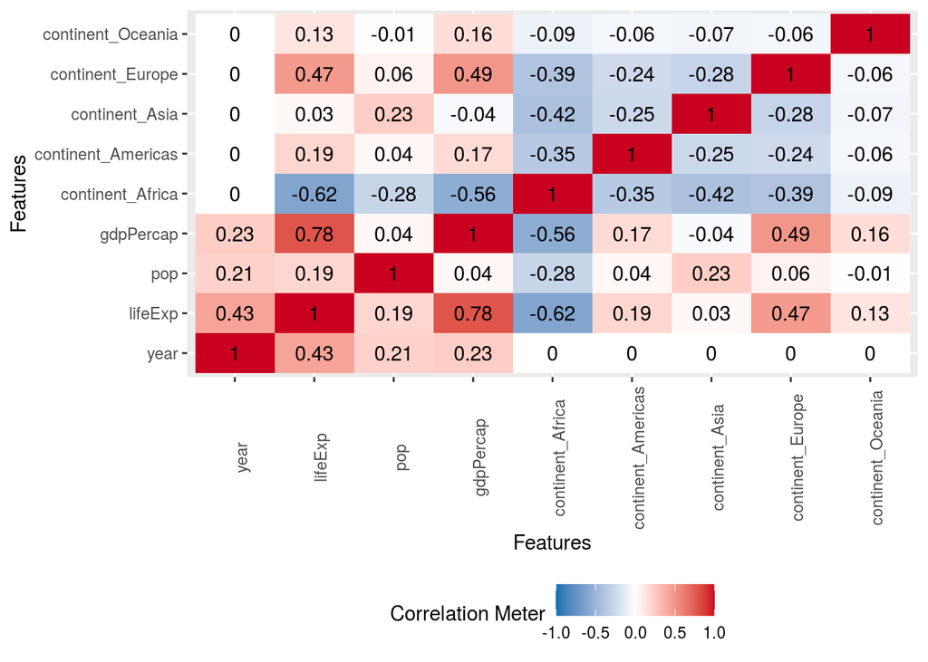

```r
# heatmat korelasi
gapminder %>%
  mutate_if(is.numeric, log) %>%
  plot_correlation()
```

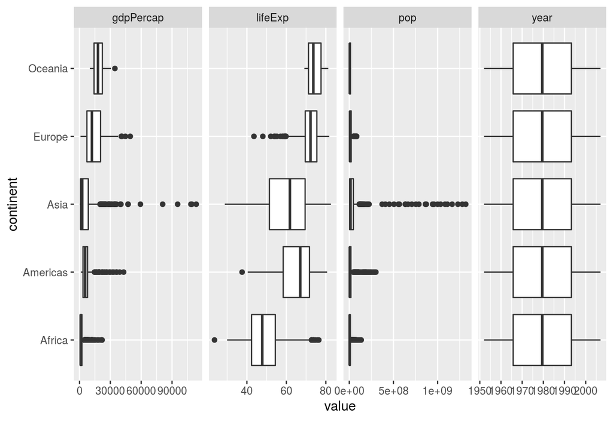

```r
# kontinu vs kategorikal
plot_boxplot(gapminder, by = "continent")
```

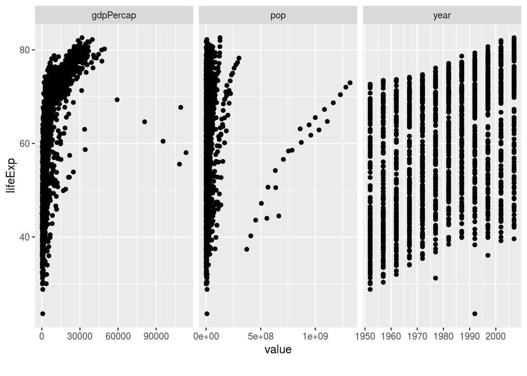

```r
# kontinu vs kontinu
gapminder %>%
  select(year:gdpPercap) %>%
  plot_scatterplot(by = "lifeExp")
```

# 8 Referensi

- [R For Data Science](https://r4ds.had.co.nz/)
- [DataExplorer](https://boxuancui.github.io/DataExplorer/)
- [Tutorial R](https://environmental-data-modeling.netlify.app/tutorial/)
- [Skimr](https://docs.ropensci.org/skimr/)